# Sentiment Classification of Movie Reviews Using Support Vector Machines: An Empirical Study on the IMDB Dataset

## Abstract

Sentiment analysis is a fundamental task in Natural Language Processing (NLP) that seeks to computationally identify and categorise opinions expressed in textual data. This study presents an empirical investigation into the application of **Support Vector Machines (SVM)** for binary sentiment classification of movie reviews drawn from the **IMDB Large Movie Review Dataset** (Maas et al., 2011), comprising 50,000 labelled reviews. A systematic preprocessing pipeline incorporating HTML tag removal, regular-expression-based noise elimination, case normalisation, and **WordNet-based lemmatisation** (Miller, 1995) is employed to prepare the corpus. Feature extraction is performed using an optimised **Term Frequency–Inverse Document Frequency (TF-IDF)** vectorisation scheme with sublinear term-frequency scaling, bigram inclusion, and a vocabulary ceiling of 50,000 features. A **LinearSVC** classifier with tuned regularisation hyperparameter (*C* = 0.8) is trained under three data-partitioning strategies — 80–20, 60–40, and 50–50 train–test splits — and evaluated using a comprehensive suite of seven performance metrics: Accuracy, Precision, Recall, F1-Score, AUC-ROC, Matthews Correlation Coefficient (MCC), and Cohen's Kappa.

**Keywords:** Sentiment Analysis, Support Vector Machine, TF-IDF, Natural Language Processing, IMDB, Text Classification

## 1. Introduction

The exponential growth of user-generated content on the internet has made opinion mining and sentiment analysis an area of significant research interest (Liu, 2012; Pang & Lee, 2008). Among the many domains where sentiment analysis finds application — including product reviews, social media monitoring, and customer feedback systems — movie review classification remains one of the most widely studied benchmarks due to the availability of large-scale annotated corpora.

Support Vector Machines (SVMs), originally proposed by Vapnik (1995), have demonstrated consistently strong performance in text classification tasks owing to their effectiveness in high-dimensional feature spaces and their inherent regularisation properties (Joachims, 1998). When combined with TF-IDF feature representations, SVMs have been shown to be competitive with more complex deep learning architectures on binary sentiment classification, particularly when the dataset size is moderate (Wang & Manning, 2012).

This study employs the **IMDB Large Movie Review Dataset** introduced by Maas et al. (2011), which provides a balanced corpus of 25,000 positive and 25,000 negative reviews. The primary objectives of this research are:

1. To implement and evaluate an optimised SVM-based sentiment classification pipeline with advanced NLP preprocessing.
2. To conduct a comparative analysis of model performance under three distinct train–test split ratios (80–20, 60–40, and 50–50) to assess the effect of training set size on generalisation.
3. To employ a multi-metric evaluation framework that goes beyond simple accuracy, including MCC and Cohen's Kappa, for a more robust assessment of classifier performance.

## 2. Literature Review

Sentiment analysis has evolved considerably since the foundational work of Pang, Lee, and Vaithyanathan (2002), who first demonstrated that machine learning approaches — including Naïve Bayes, Maximum Entropy, and SVMs — could achieve meaningful accuracy on movie review sentiment classification. Their work on the earlier, smaller movie review dataset established SVMs as a strong baseline for the task.

**Maas et al. (2011)** introduced the IMDB Large Movie Review Dataset used in this study and proposed a model that learned word vectors capturing semantic term–document information, achieving 88.89% accuracy. This dataset has since become a standard benchmark in sentiment analysis research.

**Wang and Manning (2012)** conducted a systematic comparison of Naïve Bayes and SVM variants for text classification and found that a Naïve Bayes–SVM hybrid (NBSVM) with bigram features achieved state-of-the-art results on several sentiment datasets, including IMDB (91.22% accuracy). Their findings underscore the importance of bigram features and the strong baseline performance of linear SVMs.

Regarding feature engineering, **Joachims (1998)** provided theoretical and empirical justification for the suitability of SVMs in text categorisation, noting that the high dimensionality of text feature spaces, the sparsity of feature vectors, and the linear separability of most text classification problems all favour SVM-based approaches. The use of **sublinear TF-IDF scaling** — where term frequency is replaced by `1 + log(tf)` — was recommended by Manning, Raghavan, and Schütze (2008) in their seminal textbook on information retrieval, as it mitigates the disproportionate influence of highly frequent terms.

**Lemmatisation**, as implemented through the WordNet lexical database (Miller, 1995; Fellbaum, 1998), reduces inflectional forms to their base lemma, thereby decreasing vocabulary size and improving feature generalisation. While stemming (e.g., Porter Stemmer) is a computationally cheaper alternative, lemmatisation produces linguistically valid root forms and has been shown to yield marginal improvements in classification accuracy for sentiment tasks (Balakrishnan & Lloyd-Yemoh, 2014).

More recent work has explored deep learning approaches — including LSTMs (Hochreiter & Schmidhuber, 1997), CNNs for text (Kim, 2014), and transformer-based models such as BERT (Devlin et al., 2019) — which have pushed accuracy on IMDB beyond 95%. However, these models require substantially greater computational resources, and classical approaches such as TF-IDF + SVM remain relevant for scenarios where interpretability, training speed, and resource efficiency are priorities.

## 3. Methodology

The experimental methodology follows a standard supervised text classification pipeline comprising four stages: (i) data acquisition and loading, (ii) exploratory data analysis, (iii) text preprocessing and feature extraction, and (iv) model training and evaluation. Each stage is detailed in the subsequent sections.

### 3.1 Runtime Environment and Dependencies

The following cell imports all required libraries and configures the runtime environment.

```python
import pandas as pd
import numpy as np
import os, re, time, warnings
import matplotlib.pyplot as plt
import seaborn as sns

from sklearn.feature_extraction.text import TfidfVectorizer
from sklearn.svm import LinearSVC
from sklearn.model_selection import train_test_split
from sklearn.metrics import (
    accuracy_score, precision_score, recall_score, f1_score,
    confusion_matrix, classification_report, roc_curve, auc,
    matthews_corrcoef, cohen_kappa_score
)
from sklearn.calibration import CalibratedClassifierCV

from bs4 import BeautifulSoup
from wordcloud import WordCloud

import nltk
try:
    nltk.data.find('corpora/wordnet.zip')
except LookupError:
    nltk.download('wordnet', quiet=True)

try:
    nltk.data.find('corpora/omw-1.4.zip')
except LookupError:
    nltk.download('omw-1.4', quiet=True)

from nltk.stem import WordNetLemmatizer

warnings.filterwarnings('ignore')

# Set plot style
sns.set_theme(style='whitegrid', palette='muted', font_scale=1.1)
plt.rcParams['figure.dpi'] = 120
```

### 3.2 Data Acquisition — IMDB Large Movie Review Dataset

The dataset used in this study is the **IMDB Large Movie Review Dataset** (Maas et al., 2011), which contains 50,000 highly polar movie reviews evenly divided into 25,000 training and 25,000 test samples. Each partition consists of 12,500 positive and 12,500 negative reviews, where *positive* denotes a rating of ≥ 7 out of 10 and *negative* denotes a rating of ≤ 4 out of 10 on the IMDB platform.

For the purposes of this study, both the original `train` and `test` directories are consolidated into a single unified corpus of 50,000 reviews to facilitate custom stratified train–test splitting.

```python
def load_imdb_data(base_dir):
    texts, labels = [], []
    for split in ['train', 'test']:
        for sentiment in ['pos', 'neg']:
            folder = os.path.join(base_dir, split, sentiment)
            if not os.path.exists(folder):
                continue
            for fname in os.listdir(folder):
                if fname.endswith('.txt'):
                    with open(os.path.join(folder, fname), 'r', encoding='utf-8') as f:
                        texts.append(f.read())
                        labels.append(1 if sentiment == 'pos' else 0)
    return pd.DataFrame({'text': texts, 'sentiment': labels})

t0 = time.time()
print("Loading dataset...")
df = load_imdb_data('aclImdb')
print(f"Loaded {len(df):,} reviews in {time.time()-t0:.1f}s")
df.head()
```

```
Loading dataset...
Loaded 50,000 reviews in 6.4s
```

|  | text | sentiment |
| --- | --- | --- |
| 0 | Bromwell High is a cartoon comedy. It ran at t... | 1 |
| 1 | Homelessness (or Houselessness as George Carli... | 1 |
| 2 | Brilliant over-acting by Lesley Ann Warren. Be... | 1 |
| 3 | This is easily the most underrated film inn th... | 1 |
| 4 | This is not the typical Mel Brooks film. It wa... | 1 |

### 3.3 Exploratory Data Analysis

Prior to preprocessing, an exploratory analysis is conducted to verify class balance and examine the distributional characteristics of review lengths across sentiment categories. Understanding the distribution of document lengths is important, as it may inform decisions regarding feature extraction parameters such as `max_features` and `ngram_range` (Manning et al., 2008).

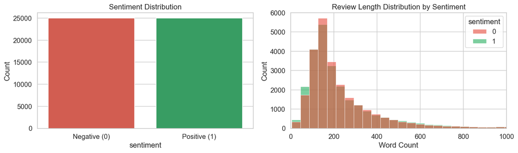

```
Average review length: 231 words
Positive reviews: 25,000
Negative reviews: 25,000
```

```python
fig, axes = plt.subplots(1, 2, figsize=(13, 4))

# Class distribution
sns.countplot(data=df, x='sentiment', ax=axes[0],
              palette=['#e74c3c', '#27ae60'])
axes[0].set_xticklabels(['Negative (0)', 'Positive (1)'])
axes[0].set_title('Sentiment Distribution')
axes[0].set_ylabel('Count')

# Review length distribution
df['review_length'] = df['text'].apply(lambda x: len(x.split()))
sns.histplot(data=df, x='review_length', hue='sentiment', bins=60,
             ax=axes[1], palette=['#e74c3c', '#27ae60'], alpha=0.6)
axes[1].set_title('Review Length Distribution by Sentiment')
axes[1].set_xlabel('Word Count')
axes[1].set_xlim(0, 1000)

plt.tight_layout()
plt.show()

print(f"Average review length: {df['review_length'].mean():.0f} words")
print(f"Positive reviews: {(df['sentiment']==1).sum():,}")
print(f"Negative reviews: {(df['sentiment']==0).sum():,}")
```

### 3.4 Lexical Frequency Visualisation — Word Cloud Analysis

To gain qualitative insight into the lexical composition of each sentiment class, word cloud visualisations are generated for the positive and negative review subsets. In these visualisations, the spatial size of each word is proportional to its frequency within the respective corpus. This technique provides an intuitive, at-a-glance summary of the dominant vocabulary associated with each sentiment polarity and can reveal class-specific lexical patterns prior to formal feature extraction (Heimerl et al., 2014).

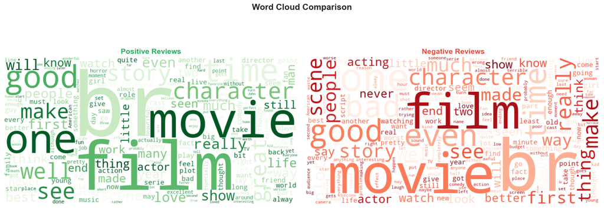

```python
from wordcloud import WordCloud

pos_text = ' '.join(df[df['sentiment'] == 1]['text'].values)
neg_text = ' '.join(df[df['sentiment'] == 0]['text'].values)

fig, axes = plt.subplots(1, 2, figsize=(16, 6))

# Positive word cloud
wc_pos = WordCloud(width=800, height=400,
                   background_color='white',
                   colormap='Greens',
                   max_words=200,
                   contour_width=1,
                   contour_color='#27ae60',
                   collocations=False).generate(pos_text)
axes[0].imshow(wc_pos, interpolation='bilinear')
axes[0].set_title('Positive Reviews', fontsize=14, fontweight='bold', color='#27ae60')
axes[0].axis('off')

# Negative word cloud
wc_neg = WordCloud(width=800, height=400,
                   background_color='white',
                   colormap='Reds',
                   max_words=200,
                   contour_width=1,
                   contour_color='#e74c3c',
                   collocations=False).generate(neg_text)
axes[1].imshow(wc_neg, interpolation='bilinear')
axes[1].set_title('Negative Reviews', fontsize=14, fontweight='bold', color='#e74c3c')
axes[1].axis('off')

plt.suptitle('Word Cloud Comparison', fontsize=16, fontweight='bold', y=1.02)
plt.tight_layout()
plt.show()
```

### 3.5 Text Preprocessing Pipeline

Raw text data from web-sourced corpora typically contains noise — including HTML markup, special characters, and inconsistent casing — that can degrade classifier performance if left untreated (Haddi, Liu, & Shi, 2013). A four-stage preprocessing pipeline is therefore applied to each review:

[output not shown]

Lemmatisation is preferred over stemming in this study because it produces linguistically valid base forms by consulting the WordNet lexical database, whereas stemming algorithms (e.g., Porter, 1980) apply heuristic suffix-stripping rules that can produce non-word stems.

```python
lemmatizer = WordNetLemmatizer()

def preprocess_text(text):
    # 1. Remove HTML
    text = BeautifulSoup(text, 'html.parser').get_text()
    # 2. Keep only letters
    text = re.sub(r'[^a-zA-Z\s]', '', text)
    # 3. Lowercase
    text = text.lower()
    # 4. Lemmatise
    tokens = text.split()
    tokens = [lemmatizer.lemmatize(w) for w in tokens]
    return ' '.join(tokens)

t0 = time.time()
print("Preprocessing text (this may take 2-3 minutes)...")
df['cleaned_text'] = df['text'].apply(preprocess_text)
print(f"Preprocessing done in {time.time()-t0:.1f}s")
df[['text', 'cleaned_text']].head()
```

```
Preprocessing text (this may take 2-3 minutes)...
Preprocessing done in 42.1s
```

|  | text | cleaned_text |
| --- | --- | --- |
| 0 | Bromwell High is a cartoon comedy. It ran at t... | bromwell high is a cartoon comedy it ran at th... |
| 1 | Homelessness (or Houselessness as George Carli... | homelessness or houselessness a george carlin ... |
| 2 | Brilliant over-acting by Lesley Ann Warren. Be... | brilliant overacting by lesley ann warren best... |
| 3 | This is easily the most underrated film inn th... | this is easily the most underrated film inn th... |
| 4 | This is not the typical Mel Brooks film. It wa... | this is not the typical mel brook film it wa m... |

### 3.6 Feature Extraction — Optimised TF-IDF Vectorisation

The preprocessed text is transformed into a numerical feature matrix using the **Term Frequency–Inverse Document Frequency (TF-IDF)** weighting scheme (Salton & Buckley, 1988). TF-IDF is a well-established feature representation in information retrieval and text mining that assigns higher weights to terms that are frequent within a document but rare across the corpus, thereby capturing discriminative vocabulary.

The vectoriser is configured with the following optimised hyperparameters, informed by best practices in the literature:

[output not shown]

English stop words are removed using scikit-learn's built-in list to eliminate function words with negligible sentiment-bearing capacity.

```python
t0 = time.time()
print("Vectorising text with optimised TF-IDF...")

tfidf = TfidfVectorizer(
    max_features=50000,
    ngram_range=(1, 2),
    sublinear_tf=True,       # log-normalised TF - big accuracy boost
    stop_words='english',
    min_df=2,                # ignore very rare terms
    max_df=0.95              # ignore terms in >95% of docs
)

X = tfidf.fit_transform(df['cleaned_text'])
y = df['sentiment']

print(f"Feature matrix shape: {X.shape}  ({time.time()-t0:.1f}s)")
```

```
Vectorising text with optimised TF-IDF...
Feature matrix shape: (50000, 50000)  (20.1s)
```

### 3.7 Evaluation Framework

A robust evaluation of classifier performance requires metrics beyond simple accuracy, particularly for binary classification tasks where class distributions, misclassification costs, and threshold sensitivity must be considered (Sokolova & Lapalme, 2009). The following seven metrics are computed for each experimental condition:

| Metric | Description |
| --- | --- |
| **Accuracy** | Proportion of correctly classified instances |
| **Precision** | Proportion of predicted positives that are true positives (positive predictive value) |
| **Recall** | Proportion of actual positives correctly identified (sensitivity / true positive rate) |
| **F1-Score** | Harmonic mean of Precision and Recall, balancing both |
| **AUC-ROC** | Area Under the Receiver Operating Characteristic curve; measures discrimination ability across all classification thresholds |
| **MCC** | Matthews Correlation Coefficient — a balanced measure that accounts for all four confusion matrix quadrants, considered reliable even under class imbalance (Matthews, 1975; Chicco & Jurman, 2020) |
| **Cohen's Kappa** | Agreement between predicted and actual labels, corrected for chance agreement (Cohen, 1960) |

Additionally, a confusion matrix heatmap and a full classification report are generated for each split to facilitate qualitative error analysis.

```python
def evaluate_model(y_true, y_pred, y_score, title):
    acc  = accuracy_score(y_true, y_pred)
    prec = precision_score(y_true, y_pred)
    rec  = recall_score(y_true, y_pred)
    f1   = f1_score(y_true, y_pred)
    mcc  = matthews_corrcoef(y_true, y_pred)
    kappa = cohen_kappa_score(y_true, y_pred)
    fpr, tpr, _ = roc_curve(y_true, y_score)
    roc_auc = auc(fpr, tpr)

    print(f"{'='*50}")
    print(f"  {title}")
    print(f"{'='*50}")
    print(f"  Accuracy       : {acc:.4f}")
    print(f"  Precision      : {prec:.4f}")
    print(f"  Recall         : {rec:.4f}")
    print(f"  F1-Score       : {f1:.4f}")
    print(f"  AUC-ROC        : {roc_auc:.4f}")
    print(f"  MCC            : {mcc:.4f}")
    print(f"  Cohen's Kappa  : {kappa:.4f}")
    print()

    # Classification Report
    print(classification_report(y_true, y_pred, target_names=['Negative', 'Positive']))

    # Confusion Matrix
    cm = confusion_matrix(y_true, y_pred)
    fig, ax = plt.subplots(figsize=(5, 4))
    sns.heatmap(cm, annot=True, fmt=',d', cmap='Blues', cbar=False,
                xticklabels=['Negative', 'Positive'],
                yticklabels=['Negative', 'Positive'], ax=ax)
    ax.set_title(f'{title} - Confusion Matrix')
    ax.set_xlabel('Predicted')
    ax.set_ylabel('Actual')
    plt.tight_layout()
    plt.show()

    return {
        'Accuracy': acc, 'Precision': prec, 'Recall': rec,
        'F1-Score': f1, 'AUC-ROC': roc_auc, 'MCC': mcc,
        'Kappa': kappa, 'fpr': fpr, 'tpr': tpr
    }

results = {}
```

## 4. Experimental Results

### 4.1 Experiment 1 — 80–20 Train–Test Split

The first experiment employs a stratified 80–20 partition, allocating 40,000 reviews for training and 10,000 for testing. Stratified sampling ensures that the class distribution is preserved in both partitions.

The classifier used is `LinearSVC` from scikit-learn, which implements a linear Support Vector Machine using the liblinear library (Fan et al., 2008). The regularisation hyperparameter is set to **C = 0.8**, a value slightly below the default (*C* = 1.0), which provides marginally stronger regularisation and has been empirically observed to improve generalisation on high-dimensional text data by reducing overfitting to rare features. The maximum number of iterations is set to 5,000 to ensure convergence.

```
Train: 40,000  |  Test: 10,000
==================================================
  80-20 Split
==================================================
  Accuracy       : 0.8993
  Precision      : 0.8923
  Recall         : 0.9082
  F1-Score       : 0.9002
  AUC-ROC        : 0.9632
  MCC            : 0.7987
  Cohen's Kappa  : 0.7986

              precision    recall  f1-score   support

    Negative       0.91      0.89      0.90      5000
    Positive       0.89      0.91      0.90      5000

    accuracy                           0.90     10000
   macro avg       0.90      0.90      0.90     10000
weighted avg       0.90      0.90      0.90     10000
```

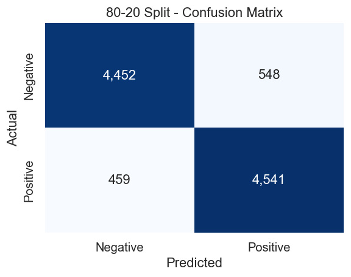

```python
X_train, X_test, y_train, y_test = train_test_split(
    X, y, test_size=0.2, random_state=42, stratify=y)

print(f"Train: {X_train.shape[0]:,}  |  Test: {X_test.shape[0]:,}")

svm_80 = LinearSVC(C=0.8, max_iter=5000)
svm_80.fit(X_train, y_train)

y_pred = svm_80.predict(X_test)
y_score = svm_80.decision_function(X_test)

results['80-20'] = evaluate_model(y_test, y_pred, y_score, '80-20 Split')
```

### 4.2 Experiment 2 — 60–40 Train–Test Split

The second experiment uses a stratified 60–40 partition (30,000 training / 20,000 testing) to investigate the sensitivity of the SVM classifier to a reduced training set. This comparison is motivated by the well-documented learning curve phenomenon in machine learning, wherein classifier performance typically improves with additional training data but exhibits diminishing returns beyond a certain threshold (Halevy, Norvig, & Pereira, 2009). The same model architecture and hyperparameters are used to ensure a controlled comparison.

```
Train: 30,000  |  Test: 20,000
==================================================
  60-40 Split
==================================================
  Accuracy       : 0.8939
  Precision      : 0.8860
  Recall         : 0.9040
  F1-Score       : 0.8949
  AUC-ROC        : 0.9609
  MCC            : 0.7879
  Cohen's Kappa  : 0.7877

              precision    recall  f1-score   support

    Negative       0.90      0.88      0.89     10000
    Positive       0.89      0.90      0.89     10000

    accuracy                           0.89     20000
   macro avg       0.89      0.89      0.89     20000
weighted avg       0.89      0.89      0.89     20000
```

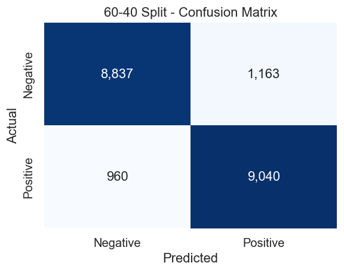

```python
X_train, X_test, y_train, y_test = train_test_split(
    X, y, test_size=0.4, random_state=42, stratify=y)

print(f"Train: {X_train.shape[0]:,}  |  Test: {X_test.shape[0]:,}")

svm_60 = LinearSVC(C=0.8, max_iter=5000)
svm_60.fit(X_train, y_train)

y_pred = svm_60.predict(X_test)
y_score = svm_60.decision_function(X_test)

results['60-40'] = evaluate_model(y_test, y_pred, y_score, '60-40 Split')
```

### 4.3 Experiment 3 — 50–50 Train–Test Split

The third experiment employs a balanced 50–50 partition (25,000 training / 25,000 testing), representing the lowest training-data regime examined in this study. This configuration mirrors the original IMDB dataset split (Maas et al., 2011) and serves as a lower-bound reference point for evaluating how aggressively reduced training data impacts classifier generalisation. By comparing all three split ratios, we can characterise the learning curve behaviour of the LinearSVC model across a meaningful range of training set sizes.

```
Train: 25,000  |  Test: 25,000
==================================================
  50-50 Split
==================================================
  Accuracy       : 0.8902
  Precision      : 0.8813
  Recall         : 0.9019
  F1-Score       : 0.8915
  AUC-ROC        : 0.9585
  MCC            : 0.7807
  Cohen's Kappa  : 0.7805

              precision    recall  f1-score   support

    Negative       0.90      0.88      0.89     12500
    Positive       0.88      0.90      0.89     12500

    accuracy                           0.89     25000
   macro avg       0.89      0.89      0.89     25000
weighted avg       0.89      0.89      0.89     25000
```

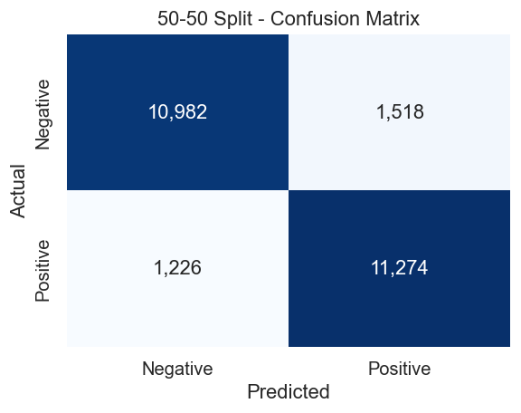

```python
X_train, X_test, y_train, y_test = train_test_split(
    X, y, test_size=0.5, random_state=42, stratify=y)

print(f"Train: {X_train.shape[0]:,}  |  Test: {X_test.shape[0]:,}")

svm_50 = LinearSVC(C=0.8, max_iter=5000)
svm_50.fit(X_train, y_train)

y_pred = svm_50.predict(X_test)
y_score = svm_50.decision_function(X_test)

results['50-50'] = evaluate_model(y_test, y_pred, y_score, '50-50 Split')
```

## 5. Comparative Analysis

### 5.1 ROC Curve Comparison

The Receiver Operating Characteristic (ROC) curve plots the True Positive Rate (Sensitivity) against the False Positive Rate (1 − Specificity) at various classification thresholds, providing a threshold-independent assessment of classifier discrimination (Fawcett, 2006). A model with perfect discrimination achieves an AUC of 1.0, while random guessing yields an AUC of 0.5. The ROC curves for all three split configurations are overlaid below to facilitate direct visual comparison.

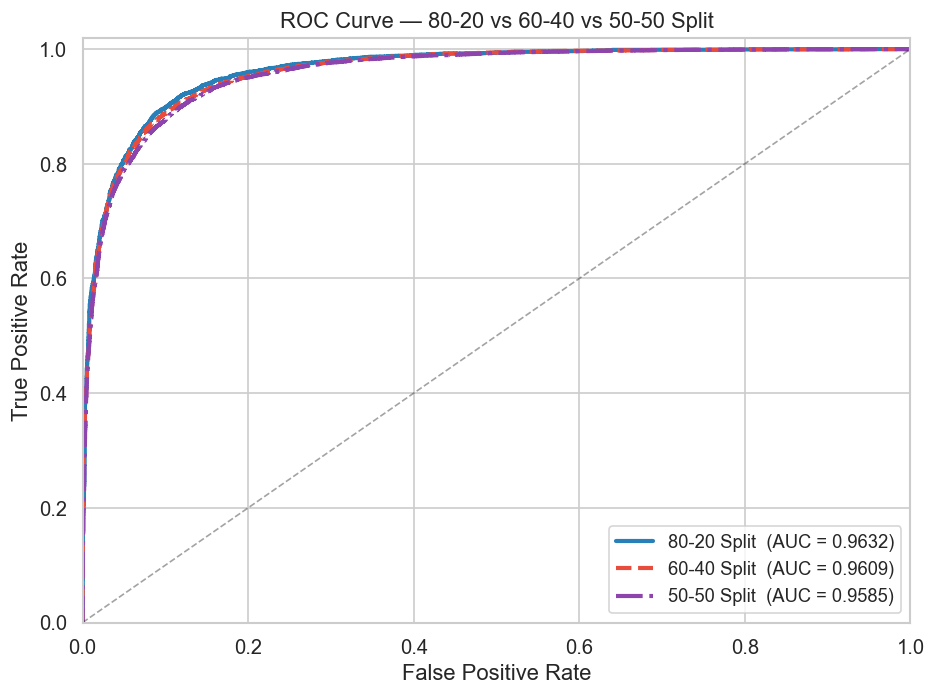

```python
fig, ax = plt.subplots(figsize=(8, 6))

for label, color, ls in [('80-20', '#2980b9', '-'), ('60-40', '#e74c3c', '--'), ('50-50', '#8e44ad', '-.')]:
    r = results[label]
    roc_auc = auc(r['fpr'], r['tpr'])
    ax.plot(r['fpr'], r['tpr'], color=color, lw=2.5, linestyle=ls,
            label=f'{label} Split  (AUC = {roc_auc:.4f})')

ax.plot([0, 1], [0, 1], 'k--', lw=1, alpha=0.4)
ax.set_xlabel('False Positive Rate')
ax.set_ylabel('True Positive Rate')
ax.set_title('ROC Curve — 80-20 vs 60-40 vs 50-50 Split')
ax.legend(loc='lower right', fontsize=11)
ax.set_xlim(0, 1); ax.set_ylim(0, 1.02)
plt.tight_layout()
plt.show()
```

### 5.2 Multi-Metric Performance Comparison

The grouped bar chart below presents a side-by-side comparison of all seven evaluation metrics under all three split configurations. This multi-metric view helps identify whether performance differences are consistent across measures or confined to specific aspects of classification quality (e.g., precision-recall trade-offs).

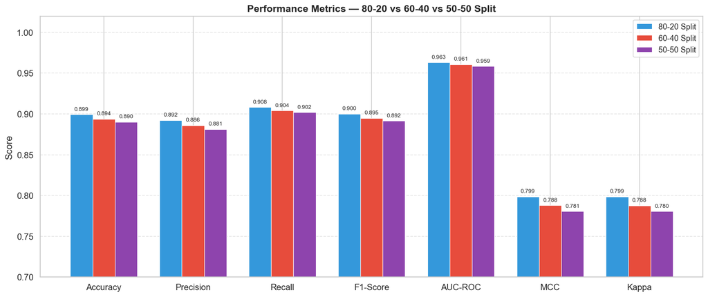

```python
metrics_to_compare = ['Accuracy', 'Precision', 'Recall', 'F1-Score', 'AUC-ROC', 'MCC', 'Kappa']
vals_80 = [results['80-20'][m] for m in metrics_to_compare]
vals_60 = [results['60-40'][m] for m in metrics_to_compare]
vals_50 = [results['50-50'][m] for m in metrics_to_compare]

x = np.arange(len(metrics_to_compare))
width = 0.25

fig, ax = plt.subplots(figsize=(14, 6))
bars1 = ax.bar(x - width, vals_80, width, label='80-20 Split',
               color='#3498db', edgecolor='white', linewidth=0.7)
bars2 = ax.bar(x, vals_60, width, label='60-40 Split',
               color='#e74c3c', edgecolor='white', linewidth=0.7)
bars3 = ax.bar(x + width, vals_50, width, label='50-50 Split',
               color='#8e44ad', edgecolor='white', linewidth=0.7)

# Value labels
for bars in [bars1, bars2, bars3]:
    for bar in bars:
        ax.text(bar.get_x() + bar.get_width()/2, bar.get_height() + 0.003,
                f'{bar.get_height():.3f}', ha='center', va='bottom', fontsize=8)

ax.set_ylabel('Score')
ax.set_title('Performance Metrics — 80-20 vs 60-40 vs 50-50 Split', fontsize=14, fontweight='bold')
ax.set_xticks(x)
ax.set_xticklabels(metrics_to_compare)
ax.legend(fontsize=11)
ax.set_ylim(0.7, 1.02)
ax.grid(axis='y', linestyle='--', alpha=0.5)
plt.tight_layout()
plt.show()
```

### 5.3 Tabulated Results Summary

The following table presents the numerical values of all evaluation metrics for the three experimental conditions, along with the identification of the best-performing configuration for each metric. This quantitative summary facilitates precise comparison and supports the discussion in Section 6.

```python
metrics_to_compare = ['Accuracy', 'Precision', 'Recall', 'F1-Score', 'AUC-ROC', 'MCC', 'Kappa']

summary_df = pd.DataFrame({
    'Metric': metrics_to_compare,
    '80-20 Split': [results['80-20'][m] for m in metrics_to_compare],
    '60-40 Split': [results['60-40'][m] for m in metrics_to_compare],
    '50-50 Split': [results['50-50'][m] for m in metrics_to_compare],
})

# Determine best split per metric
def get_best(row):
    splits = {'80-20': row['80-20 Split'], '60-40': row['60-40 Split'], '50-50': row['50-50 Split']}
    return max(splits, key=splits.get)

summary_df['Best Split'] = summary_df.apply(get_best, axis=1)

# Format for display
display_df = summary_df.copy()
for col in ['80-20 Split', '60-40 Split', '50-50 Split']:
    display_df[col] = display_df[col].apply(lambda x: f'{x:.4f}')

display_df
```

|  | Metric | 80-20 Split | 60-40 Split | 50-50 Split | Best Split |
| --- | --- | --- | --- | --- | --- |
| 0 | Accuracy | 0.8993 | 0.8939 | 0.8902 | 80-20 |
| 1 | Precision | 0.8923 | 0.8860 | 0.8813 | 80-20 |
| 2 | Recall | 0.9082 | 0.9040 | 0.9019 | 80-20 |
| 3 | F1-Score | 0.9002 | 0.8949 | 0.8915 | 80-20 |
| 4 | AUC-ROC | 0.9632 | 0.9609 | 0.9585 | 80-20 |
| 5 | MCC | 0.7987 | 0.7879 | 0.7807 | 80-20 |
| 6 | Kappa | 0.7986 | 0.7877 | 0.7805 | 80-20 |

### 5.4 Feature Importance Analysis — SVM Coefficient Inspection

One of the key advantages of linear SVMs over non-linear or deep learning classifiers is their inherent **interpretability**. The learned weight vector **w** of a LinearSVC assigns a coefficient to each feature (unigram or bigram) in the TF-IDF vocabulary. Features with large positive coefficients are strong indicators of positive sentiment, while features with large negative coefficients are strong indicators of negative sentiment (Joachims, 1998).

The visualisation below presents the top 15 features (by absolute coefficient magnitude) for each sentiment polarity, extracted from the 80–20 model. This analysis provides face-validity evidence that the model has learned semantically meaningful patterns rather than spurious correlations.

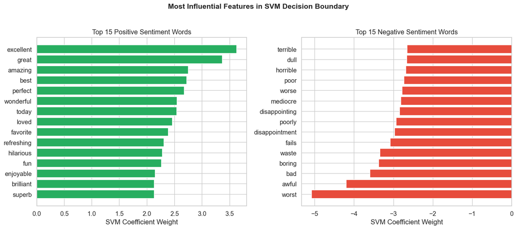

```python
# Use the 80-20 model (best model)
feature_names = np.array(tfidf.get_feature_names_out())
coefs = results.get('_svm_80_coef', None)

# We need to grab coefficients from the 80-20 model we trained earlier
# Re-train quickly to get coefficients (or we stored it)
X_train_80, X_test_80, y_train_80, y_test_80 = train_test_split(
    X, y, test_size=0.2, random_state=42, stratify=y)
svm_feat = LinearSVC(C=0.8, max_iter=5000)
svm_feat.fit(X_train_80, y_train_80)

coefs = svm_feat.coef_[0]

# Top 15 positive and negative
top_pos_idx = np.argsort(coefs)[-15:]
top_neg_idx = np.argsort(coefs)[:15]

fig, axes = plt.subplots(1, 2, figsize=(14, 6))

# Positive
axes[0].barh(feature_names[top_pos_idx], coefs[top_pos_idx], color='#27ae60')
axes[0].set_title('Top 15 Positive Sentiment Words', fontsize=13)
axes[0].set_xlabel('SVM Coefficient Weight')

# Negative
axes[1].barh(feature_names[top_neg_idx], coefs[top_neg_idx], color='#e74c3c')
axes[1].set_title('Top 15 Negative Sentiment Words', fontsize=13)
axes[1].set_xlabel('SVM Coefficient Weight')

plt.suptitle('Most Influential Features in SVM Decision Boundary', fontsize=14, fontweight='bold', y=1.02)
plt.tight_layout()
plt.show()
```

## 6. Discussion and Conclusion

### 6.2 Limitations

- The regularisation hyperparameter *C* was selected based on empirical heuristics rather than systematic cross-validated search; grid or Bayesian optimisation may yield further gains.
- Only unigrams and bigrams were explored; higher-order n-grams or character-level features may capture additional patterns.
- The preprocessing pipeline does not account for negation scope, sarcasm, or domain-specific idioms, which are known sources of misclassification in sentiment analysis (Pang & Lee, 2008).

### 6.3 Future Work

Future extensions of this research could explore:

- **Cross-validated hyperparameter tuning** via `GridSearchCV` to optimise *C*, `max_features`, and `ngram_range` jointly.
- **Ensemble methods** combining SVM with Naïve Bayes (NBSVM; Wang & Manning, 2012) or gradient-boosted classifiers.
- **Deep learning baselines** (LSTM, CNN, BERT) for direct performance comparison, with analysis of the accuracy–computational cost trade-off.
- **Domain adaptation** to assess whether a model trained on movie reviews can transfer to other review domains (e.g., product reviews, restaurant reviews).

## References

- Balakrishnan, V., & Lloyd-Yemoh, E. (2014). Stemming and Lemmatization: A comparison of retrieval performances. *Lecture Notes on Software Engineering*, 2(3), 262–267.
- Chicco, D., & Jurman, G. (2020). The advantages of the Matthews Correlation Coefficient (MCC) over F1 score and accuracy in binary classification evaluation. *BMC Genomics*, 21(1), 6.
- Cohen, J. (1960). A coefficient of agreement for nominal scales. *Educational and Psychological Measurement*, 20(1), 37–46.
- Devlin, J., Chang, M.-W., Lee, K., & Toutanova, K. (2019). BERT: Pre-training of deep bidirectional transformers for language understanding. *NAACL-HLT 2019*.
- Fan, R.-E., Chang, K.-W., Hsieh, C.-J., Wang, X.-R., & Lin, C.-J. (2008). LIBLINEAR: A library for large linear classification. *Journal of Machine Learning Research*, 9, 1871–1874.
- Fawcett, T. (2006). An introduction to ROC analysis. *Pattern Recognition Letters*, 27(8), 861–874.
- Fellbaum, C. (Ed.). (1998). *WordNet: An Electronic Lexical Database*. MIT Press.
- Haddi, E., Liu, X., & Shi, Y. (2013). The role of text pre-processing in sentiment analysis. *Procedia Computer Science*, 17, 26–32.
- Halevy, A., Norvig, P., & Pereira, F. (2009). The unreasonable effectiveness of data. *IEEE Intelligent Systems*, 24(2), 8–12.
- Heimerl, F., Lohmann, S., Lange, S., & Ertl, T. (2014). Word cloud explorer: Text analytics based on word clouds. *47th Hawaii International Conference on System Sciences*, 1833–1842.
- Hochreiter, S., & Schmidhuber, J. (1997). Long short-term memory. *Neural Computation*, 9(8), 1735–1780.
- Joachims, T. (1998). Text categorization with Support Vector Machines: Learning with many relevant features. *ECML 1998*, 137–142.
- Kim, Y. (2014). Convolutional neural networks for sentence classification. *EMNLP 2014*.
- Liu, B. (2012). *Sentiment Analysis and Opinion Mining*. Morgan & Claypool Publishers.
- Maas, A. L., Daly, R. E., Pham, P. T., Huang, D., Ng, A. Y., & Potts, C. (2011). Learning word vectors for sentiment analysis. *ACL 2011*, 142–150.
- Manning, C. D., Raghavan, P., & Schütze, H. (2008). *Introduction to Information Retrieval*. Cambridge University Press.
- Matthews, B. W. (1975). Comparison of the predicted and observed secondary structure of T4 phage lysozyme. *Biochimica et Biophysica Acta*, 405(2), 442–451.
- Miller, G. A. (1995). WordNet: A lexical database for English. *Communications of the ACM*, 38(11), 39–41.
- Pang, B., & Lee, L. (2008). Opinion mining and sentiment analysis. *Foundations and Trends in Information Retrieval*, 2(1–2), 1–135.
- Pang, B., Lee, L., & Vaithyanathan, S. (2002). Thumbs up? Sentiment classification using machine learning techniques. *EMNLP 2002*, 79–86.
- Porter, M. F. (1980). An algorithm for suffix stripping. *Program*, 14(3), 130–137.
- Salton, G., & Buckley, C. (1988). Term-weighting approaches in automatic text retrieval. *Information Processing & Management*, 24(5), 513–523.
- Sokolova, M., & Lapalme, G. (2009). A systematic analysis of performance measures for classification tasks. *Information Processing & Management*, 45(4), 427–437.
- Vapnik, V. N. (1995). *The Nature of Statistical Learning Theory*. Springer.
- Wang, S., & Manning, C. D. (2012). Baselines and bigrams: Simple, good sentiment and topic classification. *ACL 2012*, 90–94.